# PML Assignment2

Martijn

9 januari 2017

## Course Project Practical Machine Learning

#### Introduction and sypnosis

The datasets are the results from an experiment described here: `http://groupware.les.inf.puc-rio.br/har` In short, there were 6 participants who where asked to do a repeated Unilateral Dumbbell Biceps Curl exercise in 5 different ways, each labeled by a letter: A, B, C, D and E. A is exactly according to the explanation, while B-E are all faulty in a different way. In this course project, we’re going to create two models to learn from the data in order to predict in which manner a participant performed his/her exercises.

#### Download the files and read them

```r
if (!file.exists("pml_training.csv")) {
    download.file("https://d396qusza40orc.cloudfront.net/predmachlearn/pml-training.csv",
                  destfile = "pml_training.csv")
}

if(!file.exists("pml_testing.csv")) {
    download.file('https://d396qusza40orc.cloudfront.net/predmachlearn/pml-testing.csv',
    destfile = "pml_testing.csv")
}

training <- read.csv("pml_training.csv", na.strings = c("NA", "", "#DIV/0!"))
testing <- read.csv("pml_testing.csv", na.strings = c("NA", "", "#DIV/0!"))
```

## Exploratory Data analysis

Let’s observe the data to get an idea what is contained in each of the datasets.

```r
str(training)
```

```
## 'data.frame':    19622 obs. of  160 variables:
##  $ X                       : int  1 2 3 4 5 6 7 8 9 10 ...
##  $ user_name               : Factor w/ 6 levels "adelmo","carlitos",..: 2 2 2 2 2 2 2 2 2 2 ...
##  $ raw_timestamp_part_1    : int  1323084231 1323084231 1323084231 1323084232 1323084232 1323084232 1323084232 1323084232 1323084232 1323084232 ...
##  $ raw_timestamp_part_2    : int  788290 808298 820366 120339 196328 304277 368296 440390 484323 484434 ...
##  $ cvtd_timestamp          : Factor w/ 20 levels "02/12/2011 13:32",..: 9 9 9 9 9 9 9 9 9 9 ...
##  $ new_window              : Factor w/ 2 levels "no","yes": 1 1 1 1 1 1 1 1 1 1 ...
##  $ num_window              : int  11 11 11 12 12 12 12 12 12 12 ...
##  $ roll_belt               : num  1.41 1.41 1.42 1.48 1.48 1.45 1.42 1.42 1.43 1.45 ...
##  $ pitch_belt              : num  8.07 8.07 8.07 8.05 8.07 8.06 8.09 8.13 8.16 8.17 ...
##  $ yaw_belt                : num  -94.4 -94.4 -94.4 -94.4 -94.4 -94.4 -94.4 -94.4 -94.4 -94.4 ...
##  $ total_accel_belt        : int  3 3 3 3 3 3 3 3 3 3 ...
##  $ kurtosis_roll_belt      : num  NA NA NA NA NA NA NA NA NA NA ...
##  $ kurtosis_picth_belt     : num  NA NA NA NA NA NA NA NA NA NA ...
##  $ kurtosis_yaw_belt       : logi  NA NA NA NA NA NA ...
```

[output cut: 86 more lines]

```r
library(caret)
library(rpart)
library(randomForest)
library(rattle)
set.seed(95831)
```

## Reshaping the data

As we observe from the data structure, these datasets contains a large amount of NA’s. Some variables/columns consist almost solely out of NA’s and thus don’t seem to be important in estimation and prediction. First I decide to remove those columns that contain over 80% NA values from the testing set. Next, I remove the first columns, containg names and dates, as we wish to predict the type of action performed based on the data measured by the tool/app. Finally, I apply the same filters to the training datase:

```r
new_test <- testing[, colSums(is.na(testing)) < 0.8 * nrow(testing)]
columns2brm <- colnames(testing[, colSums(is.na(testing)) > 0.8*nrow(testing)])
columns2brm <- c(columns2brm)
new_train <- training[, !(colnames(training) %in% columns2brm)]
testing <- testing[, !(colnames(testing) %in% columns2brm)]
new_testing <- testing[,-60]
new_testing <- new_testing[, -c(1:7)]
new_training <- new_train[, -c(1:7)]
```

Now that the training and testing datasets contain the same variables, I will divide the training set in a train and test set as well, in order to validate the accuracy of fitted models.

```r
set.seed(97531)
inTrain <- createDataPartition(y= new_train$classe, p = 0.6, list = FALSE)
train_train <- new_train[inTrain,]
test_train <- new_train[-inTrain,]

inTrain <- createDataPartition(y= new_training$classe, p = 0.6, list = FALSE)
train_train <- new_training[inTrain,]
test_train <- new_training[-inTrain,]
```

Now we try fitting a classification tree:

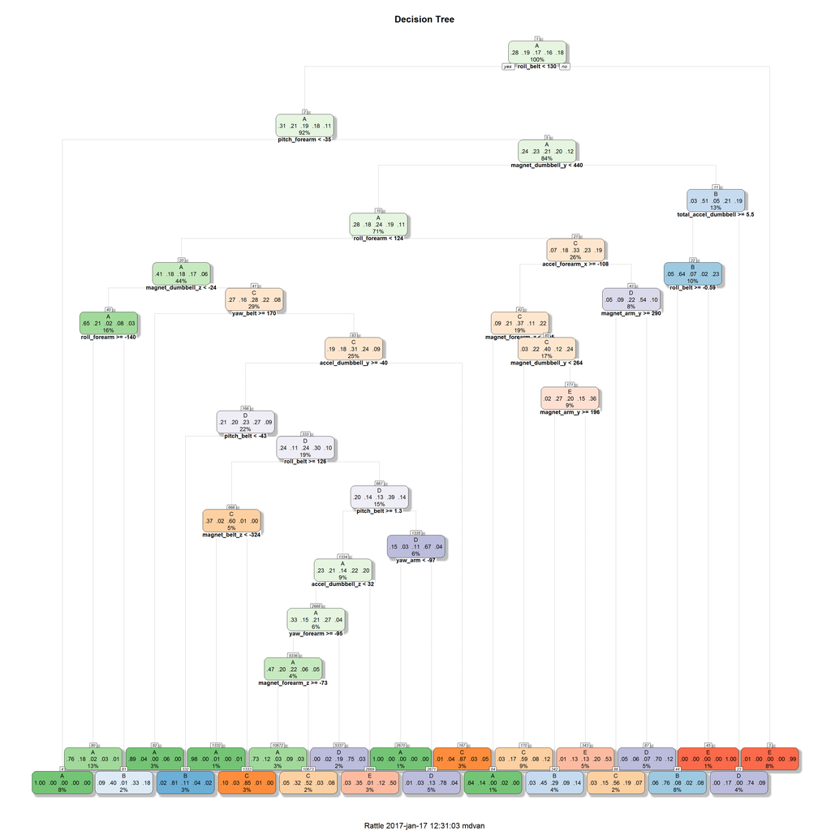

```r
## rpart
rpy <- rpart(classe ~ ., data = train_train, method = "class")
fancyRpartPlot(rpy, main = "Decision Tree", cex = 0.75)
```

```r
prp <- predict(rpy, newdata = test_train, type = "class")
confusionMatrix(data = prp, reference = test_train$classe)
```

```
## Confusion Matrix and Statistics
##
##           Reference
## Prediction    A    B    C    D    E
##          A 2044  246   32   86   14
##          B   60  838  130  109  118
##          C   58  185 1065  104  117
##          D   41   97   90  883  110
##          E   29  152   51  104 1083
##
## Overall Statistics
##
##                Accuracy : 0.7536
##                  95% CI : (0.7439, 0.7631)
##     No Information Rate : 0.2845
##     P-Value [Acc > NIR] : < 2.2e-16
##
##                   Kappa : 0.6876
##  Mcnemar's Test P-Value : < 2.2e-16
##
## Statistics by Class:
##
##                      Class: A Class: B Class: C Class: D Class: E
## Sensitivity            0.9158   0.5520   0.7785   0.6866   0.7510
## Specificity            0.9327   0.9341   0.9284   0.9485   0.9475
## Pos Pred Value         0.8439   0.6677   0.6965   0.7232   0.7632
## Neg Pred Value         0.9653   0.8968   0.9520   0.9392   0.9441
## Prevalence             0.2845   0.1935   0.1744   0.1639   0.1838
## Detection Rate         0.2605   0.1068   0.1357   0.1125   0.1380
## Detection Prevalence   0.3087   0.1600   0.1949   0.1556   0.1809
## Balanced Accuracy      0.9242   0.7431   0.8534   0.8176   0.8493
```

Using a classification tree, we get an accuracy of approximately 75%, which means that the out of sample error is approximately 25%. Since we aim for a higher accuracy, we’ll try fitting a random forest model. Since there is a chance of overfitting, I’ll use cross-validation with 4 folds in the dataset.

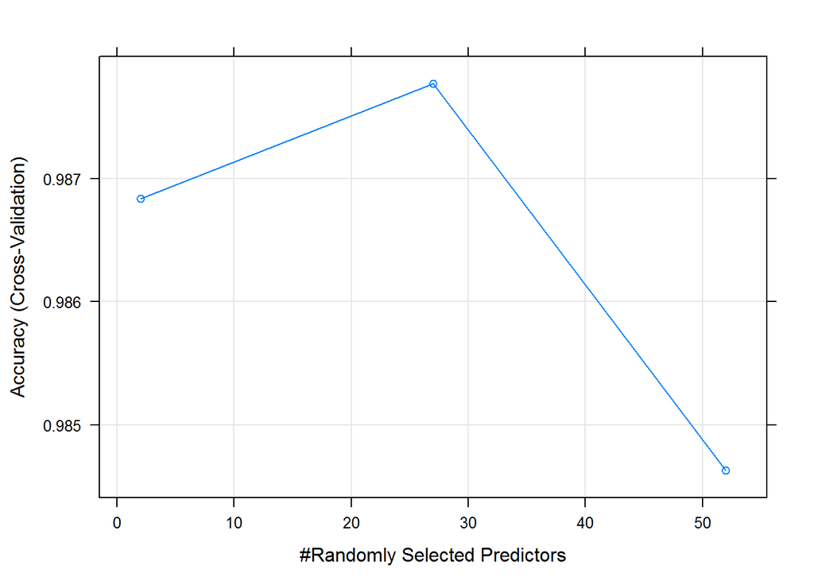

```r
### random forest
rf_mod <- train(classe ~ ., method="rf", data=train_train, trControl=trainControl(method = "cv", number = 4))
plot(rf_mod)
```

```r
prf <- predict(rf_mod$finalModel, newdata = test_train, type = "class")
conf_mat <- confusionMatrix(prf, reference = test_train$classe)
conf_mat
```

```
## Confusion Matrix and Statistics
##
##           Reference
## Prediction    A    B    C    D    E
##          A 2226   10    0    0    0
##          B    4 1508   14    1    1
##          C    0    0 1348    6    2
##          D    0    0    6 1275    6
##          E    2    0    0    4 1433
##
## Overall Statistics
##
##                Accuracy : 0.9929
##                  95% CI : (0.9907, 0.9946)
##     No Information Rate : 0.2845
##     P-Value [Acc > NIR] : < 2.2e-16
##
##                   Kappa : 0.991
##  Mcnemar's Test P-Value : NA
##
## Statistics by Class:
##
##                      Class: A Class: B Class: C Class: D Class: E
## Sensitivity            0.9973   0.9934   0.9854   0.9914   0.9938
## Specificity            0.9982   0.9968   0.9988   0.9982   0.9991
## Pos Pred Value         0.9955   0.9869   0.9941   0.9907   0.9958
## Neg Pred Value         0.9989   0.9984   0.9969   0.9983   0.9986
## Prevalence             0.2845   0.1935   0.1744   0.1639   0.1838
## Detection Rate         0.2837   0.1922   0.1718   0.1625   0.1826
## Detection Prevalence   0.2850   0.1947   0.1728   0.1640   0.1834
## Balanced Accuracy      0.9978   0.9951   0.9921   0.9948   0.9964
```

```r
set.seed(97531)
final_prediction <- predict(rf_mod$finalModel, newdata = new_testing)
final_prediction
```

```
##  1  2  3  4  5  6  7  8  9 10 11 12 13 14 15 16 17 18 19 20
##  B  A  B  A  A  E  D  B  A  A  B  C  B  A  E  E  A  B  B  B
## Levels: A B C D E
```